# Return Home

[View Code on Github](https://github.com/JohnKimaiyo/Business-Analytics-Power-BI/blob/main/Projects/Webscraping%20Projects/10%20Top%20Cloud%20Service%20Providers%20%26%20Companies%20for%202024.ipynb)

# 10 Top Cloud Service Providers & Companies for 2024

## 1.Amazon Web Services (AWS)

Amazon Web Services, Inc. is a subsidiary of Amazon that provides on-demand cloud computing platforms and APIs to individuals, companies, and governments, on a metered, pay-as-you-go basis. Clients will often use this in combination with autoscaling.

## 2.Microsoft Azure

Microsoft Azure, often referred to as Azure, is a cloud computing platform run by Microsoft. It offers access, management, and the development of applications and services through global data centers

## 3.Salesforce

Salesforce, Inc. is an American cloud-based software company headquartered in San Francisco, California. It provides customer relationship management software and applications focused on sales, customer service, marketing automation, e-commerce, analytics, and application development

## 4.VMWare

VMware LLC is an American cloud computing and virtualization technology company with headquarters in Palo Alto, California. VMware was the first commercially successful company to virtualize the x86 architecture. VMware's desktop software runs on Microsoft Windows, Linux, and macOS.

## 5.Alibaba Cloud

Alibaba Cloud, also known as Aliyun, is a cloud computing company, a subsidiary of Alibaba Group. Alibaba Cloud provides cloud computing services to online businesses and Alibaba's own e-commerce ecosystem.

## 6.Oracle

Oracle Corporation is an American multinational computer technology company headquartered in Austin, Texas, United States. In 2020, Oracle was the third-largest software company in the world by revenue and market capitalization.

## 7.Rackspace

Rackspace Technology, Inc. is an American cloud computing company based in Windcrest, Texas, an inner suburb of San Antonio, Texas.

## 8.Digital Ocean

DigitalOcean Holdings, Inc. is an American multinational technology company and cloud service provider. The company is headquartered in New York City, New York, US, with 15 globally distributed data centers. DigitalOcean provides developers, startups, and SMBs with cloud infrastructure-as-a-service platforms.

## 9.ServiceNow

ServiceNow, Inc. is an American software company based in Santa Clara, California that develops a cloud computing platform to help companies manage digital workflows for enterprise operations.

## 10.NetApp

NetApp, Inc. is an intelligent data infrastructure company that provides unified data storage, integrated data services, and cloud operations solutions to enterprise customers. The company is based in San Jose, California. It has ranked in the Fortune 500 from 2012 to 2021

```python
# lets import libraries
from googleapiclient.discovery import build
import pandas as pd
import seaborn as sns
```

## 1.Amazon Web Services (AWS)

```python
api_key = 'AIzaSyB24Kop04L1GlTgRCm1XtQ4KB2a4gaBOwA'
Amazon_Web_Services_channel_id = ['UCd6MoB9NC6uYN2grvUNT-Zg' # Amazon Web Services

              ]
youtube = build('youtube','v3',developerKey = api_key)

from googleapiclient.errors import HttpError

def get_channel_stats(youtube, Amazon_Web_Services_channel_id):
    all_data = []
    try:
        request = youtube.channels().list(
            part='snippet,contentDetails,statistics',
            id=','.join(Amazon_Web_Services_channel_id)
        )
        response = request.execute()

        for item in response.get('items', []):
            snippet = item.get('snippet', {})
            statistics = item.get('statistics', {})

            data = {
                'Channel_name': snippet.get('title', ''),
                'Subscribers': statistics.get('subscriberCount', ''),
                'Views': statistics.get('viewCount', ''),
                'Total_videos': statistics.get('videoCount', '')
            }

            all_data.append(data)

    except HttpError as e:
        print(f"HTTP error occurred: {e}")
        print(f"Request URL: {e.resp.request.url}")
        print(f"Request body: {e.resp.request.body}")

    return all_data
```

```python
get_channel_stats(youtube,Amazon_Web_Services_channel_id)
```

```
[{'Channel_name': 'Amazon Web Services',
  'Subscribers': '728000',
  'Views': '176423729',
  'Total_videos': '16042'}]
```

```python
channel_statistics = get_channel_stats(youtube, Amazon_Web_Services_channel_id)
```

```python
Amazon_Web_Services_channel_data =pd.DataFrame(channel_statistics)
```

```python
Amazon_Web_Services_channel_data
```

|  | Channel_name | Subscribers | Views | Total_videos |
| --- | --- | --- | --- | --- |
| 0 | Amazon Web Services | 728000 | 176423729 | 16042 |

## 2.Microsoft Azure

```python
api_key = 'AIzaSyB24Kop04L1GlTgRCm1XtQ4KB2a4gaBOwA'
Microsoft_Azure_channel_id = ['UC0m-80FnNY2Qb7obvTL_2fA' # Microsoft Azure

              ]
youtube = build('youtube','v3',developerKey = api_key)

from googleapiclient.errors import HttpError

def get_channel_stats(youtube, Microsoft_Azure_channel_id):
    all_data = []
    try:
        request = youtube.channels().list(
            part='snippet,contentDetails,statistics',
            id=','.join(Microsoft_Azure_channel_id)
        )
        response = request.execute()

        for item in response.get('items', []):
            snippet = item.get('snippet', {})
            statistics = item.get('statistics', {})

            data = {
                'Channel_name': snippet.get('title', ''),
                'Subscribers': statistics.get('subscriberCount', ''),
                'Views': statistics.get('viewCount', ''),
                'Total_videos': statistics.get('videoCount', '')
            }

            all_data.append(data)

    except HttpError as e:
        print(f"HTTP error occurred: {e}")
        print(f"Request URL: {e.resp.request.url}")
        print(f"Request body: {e.resp.request.body}")

    return all_data
```

```python
get_channel_stats(youtube, Microsoft_Azure_channel_id)
```

```
[{'Channel_name': 'Microsoft Azure',
  'Subscribers': '306000',
  'Views': '25056291',
  'Total_videos': '1509'}]
```

```python
channel_statistics = get_channel_stats(youtube, Microsoft_Azure_channel_id)
```

```python
Microsoft_Azure_channel_data =pd.DataFrame(channel_statistics)
```

```python
Microsoft_Azure_channel_data
```

|  | Channel_name | Subscribers | Views | Total_videos |
| --- | --- | --- | --- | --- |
| 0 | Microsoft Azure | 306000 | 25056291 | 1509 |

## 3.Salesforce

```python
api_key = 'AIzaSyB24Kop04L1GlTgRCm1XtQ4KB2a4gaBOwA'
Salesforce_channel_id = ['UCUpquzY878NEaZm5bc7m2sQ' # Salesforce

              ]
youtube = build('youtube','v3',developerKey = api_key)

from googleapiclient.errors import HttpError

def get_channel_stats(youtube, Salesforce_channel_id):
    all_data = []
    try:
        request = youtube.channels().list(
            part='snippet,contentDetails,statistics',
            id=','.join(Salesforce_channel_id)
        )
        response = request.execute()

        for item in response.get('items', []):
            snippet = item.get('snippet', {})
            statistics = item.get('statistics', {})

            data = {
                'Channel_name': snippet.get('title', ''),
                'Subscribers': statistics.get('subscriberCount', ''),
                'Views': statistics.get('viewCount', ''),
                'Total_videos': statistics.get('videoCount', '')
            }

            all_data.append(data)

    except HttpError as e:
        print(f"HTTP error occurred: {e}")
        print(f"Request URL: {e.resp.request.url}")
        print(f"Request body: {e.resp.request.body}")

    return all_data
```

```python
get_channel_stats(youtube, Salesforce_channel_id)
```

```
[{'Channel_name': 'Salesforce',
  'Subscribers': '814000',
  'Views': '188325513',
  'Total_videos': '1199'}]
```

```python
channel_statistics = get_channel_stats(youtube, Salesforce_channel_id)
```

```python
Salesforce_channel_data =pd.DataFrame(channel_statistics)
```

```python
Salesforce_channel_data
```

|  | Channel_name | Subscribers | Views | Total_videos |
| --- | --- | --- | --- | --- |
| 0 | Salesforce | 814000 | 188325513 | 1199 |

## 4.VMWare

```python
api_key = 'AIzaSyB24Kop04L1GlTgRCm1XtQ4KB2a4gaBOwA'
VMWare_channel_id = ['UCZTvfJMhQ5Oc5TFw465tcJQ' # VMWare

              ]
youtube = build('youtube','v3',developerKey = api_key)

from googleapiclient.errors import HttpError

def get_channel_stats(youtube, VMWare_channel_id):
    all_data = []
    try:
        request = youtube.channels().list(
            part='snippet,contentDetails,statistics',
            id=','.join(VMWare_channel_id)
        )
        response = request.execute()

        for item in response.get('items', []):
            snippet = item.get('snippet', {})
            statistics = item.get('statistics', {})

            data = {
                'Channel_name': snippet.get('title', ''),
                'Subscribers': statistics.get('subscriberCount', ''),
                'Views': statistics.get('viewCount', ''),
                'Total_videos': statistics.get('videoCount', '')
            }

            all_data.append(data)

    except HttpError as e:
        print(f"HTTP error occurred: {e}")
        print(f"Request URL: {e.resp.request.url}")
        print(f"Request body: {e.resp.request.body}")

    return all_data
```

```python
channel_statistics = get_channel_stats(youtube, VMWare_channel_id)
```

```python
VMWare_channel_data =pd.DataFrame(channel_statistics)
```

```python
VMWare_channel_data
```

|  | Channel_name | Subscribers | Views | Total_videos |
| --- | --- | --- | --- | --- |
| 0 | VMware | 99200 | 96398711 | 3229 |

```python
api_key = 'AIzaSyB24Kop04L1GlTgRCm1XtQ4KB2a4gaBOwA'
Alibaba_Cloud_channel_id = ['UCipPA-ZHX6UYGH_Iyti1-Jw' # Alibaba Cloud

              ]
youtube = build('youtube','v3',developerKey = api_key)

from googleapiclient.errors import HttpError

def get_channel_stats(youtube, Alibaba_Cloud_channel_id):
    all_data = []
    try:
        request = youtube.channels().list(
            part='snippet,contentDetails,statistics',
            id=','.join(Alibaba_Cloud_channel_id )
        )
        response = request.execute()

        for item in response.get('items', []):
            snippet = item.get('snippet', {})
            statistics = item.get('statistics', {})

            data = {
                'Channel_name': snippet.get('title', ''),
                'Subscribers': statistics.get('subscriberCount', ''),
                'Views': statistics.get('viewCount', ''),
                'Total_videos': statistics.get('videoCount', '')
            }

            all_data.append(data)

    except HttpError as e:
        print(f"HTTP error occurred: {e}")
        print(f"Request URL: {e.resp.request.url}")
        print(f"Request body: {e.resp.request.body}")
```

```python
get_channel_stats(youtube, Alibaba_Cloud_channel_id )
```

```python
Alibaba_Cloud_channel_data =pd.DataFrame(channel_statistics)
```

```python
Alibaba_Cloud_channel_data
```

[output not shown]

## 6.Oracle

```python
api_key = 'AIzaSyB24Kop04L1GlTgRCm1XtQ4KB2a4gaBOwA'
Oracle_channel_id = ['UCHCThmyZ-2yWkv0UVeBDdnQ' # Oracle

              ]
youtube = build('youtube','v3',developerKey = api_key)

from googleapiclient.errors import HttpError

def get_channel_stats(youtube, Oracle_channel_id):
    all_data = []
    try:
        request = youtube.channels().list(
            part='snippet,contentDetails,statistics',
            id=','.join(Oracle_channel_id)
        )
        response = request.execute()

        for item in response.get('items', []):
            snippet = item.get('snippet', {})
            statistics = item.get('statistics', {})

            data = {
                'Channel_name': snippet.get('title', ''),
                'Subscribers': statistics.get('subscriberCount', ''),
                'Views': statistics.get('viewCount', ''),
                'Total_videos': statistics.get('videoCount', '')
            }

            all_data.append(data)

    except HttpError as e:
        print(f"HTTP error occurred: {e}")
        print(f"Request URL: {e.resp.request.url}")
        print(f"Request body: {e.resp.request.body}")

    return all_data
```

```python
get_channel_stats(youtube, Oracle_channel_id)
```

```
[{'Channel_name': 'Oracle',
  'Subscribers': '126000',
  'Views': '35753084',
  'Total_videos': '4341'}]
```

```python
channel_statistics = get_channel_stats(youtube, Oracle_channel_id)
```

```python
Oracle_channel_data =pd.DataFrame(channel_statistics)
```

```python
Oracle_channel_data
```

|  | Channel_name | Subscribers | Views | Total_videos |
| --- | --- | --- | --- | --- |
| 0 | Oracle | 126000 | 35753084 | 4341 |

## 7.Rackspace

```python
api_key = 'AIzaSyB24Kop04L1GlTgRCm1XtQ4KB2a4gaBOwA'
Rackspace_channel_id = ['UCG0VI_ayS-I0RQpBna4Tisw' # Rackspace

              ]
youtube = build('youtube','v3',developerKey = api_key)

from googleapiclient.errors import HttpError

def get_channel_stats(youtube, Rackspace_channel_id):
    all_data = []
    try:
        request = youtube.channels().list(
            part='snippet,contentDetails,statistics',
            id=','.join(Rackspace_channel_id)
        )
        response = request.execute()

        for item in response.get('items', []):
            snippet = item.get('snippet', {})
            statistics = item.get('statistics', {})

            data = {
                'Channel_name': snippet.get('title', ''),
                'Subscribers': statistics.get('subscriberCount', ''),
                'Views': statistics.get('viewCount', ''),
                'Total_videos': statistics.get('videoCount', '')
            }

            all_data.append(data)

    except HttpError as e:
        print(f"HTTP error occurred: {e}")
        print(f"Request URL: {e.resp.request.url}")
        print(f"Request body: {e.resp.request.body}")

    return all_data
```

```python
get_channel_stats(youtube, Rackspace_channel_id)
```

```
[{'Channel_name': 'Rackspace Technology',
  'Subscribers': '28700',
  'Views': '10283456',
  'Total_videos': '1139'}]
```

```python
channel_statistics = get_channel_stats(youtube, Rackspace_channel_id)
```

```python
Rackspace_channel_data =pd.DataFrame(channel_statistics)
```

```python
Rackspace_channel_data
```

|  | Channel_name | Subscribers | Views | Total_videos |
| --- | --- | --- | --- | --- |
| 0 | Rackspace Technology | 28700 | 10283456 | 1139 |

## 8.Digital Ocean

```python
api_key = 'AIzaSyB24Kop04L1GlTgRCm1XtQ4KB2a4gaBOwA'
Digital_Ocean_channel_id = ['UCaPX53JLxxSbwZz_Ra_cL0g' # Digital Ocean

              ]
youtube = build('youtube','v3',developerKey = api_key)

from googleapiclient.errors import HttpError

def get_channel_stats(youtube, Digital_Ocean_channel_id):
    all_data = []
    try:
        request = youtube.channels().list(
            part='snippet,contentDetails,statistics',
            id=','.join(Digital_Ocean_channel_id)
        )
        response = request.execute()

        for item in response.get('items', []):
            snippet = item.get('snippet', {})
            statistics = item.get('statistics', {})

            data = {
                'Channel_name': snippet.get('title', ''),
                'Subscribers': statistics.get('subscriberCount', ''),
                'Views': statistics.get('viewCount', ''),
                'Total_videos': statistics.get('videoCount', '')
            }

            all_data.append(data)

    except HttpError as e:
        print(f"HTTP error occurred: {e}")
        print(f"Request URL: {e.resp.request.url}")
        print(f"Request body: {e.resp.request.body}")

    return all_data
```

```python
get_channel_stats(youtube, Digital_Ocean_channel_id)
```

```
[{'Channel_name': 'DigitalOcean',
  'Subscribers': '53900',
  'Views': '19323262',
  'Total_videos': '1106'}]
```

```python
channel_statistics = get_channel_stats(youtube, Digital_Ocean_channel_id)
```

```python
Digital_Ocean_channel_data =pd.DataFrame(channel_statistics)
```

```python
Digital_Ocean_channel_data
```

|  | Channel_name | Subscribers | Views | Total_videos |
| --- | --- | --- | --- | --- |
| 0 | DigitalOcean | 53900 | 19323262 | 1106 |

## 9.ServiceNow

```python
api_key = 'AIzaSyB24Kop04L1GlTgRCm1XtQ4KB2a4gaBOwA'
ServiceNow_channel_id = ['UCLukrOQYSgsHUR_NSiVZndQ' # ServiceNow

              ]
youtube = build('youtube','v3',developerKey = api_key)

from googleapiclient.errors import HttpError

def get_channel_stats(youtube, ServiceNow_channel_id):
    all_data = []
    try:
        request = youtube.channels().list(
            part='snippet,contentDetails,statistics',
            id=','.join(ServiceNow_channel_id)
        )
        response = request.execute()

        for item in response.get('items', []):
            snippet = item.get('snippet', {})
            statistics = item.get('statistics', {})

            data = {
                'Channel_name': snippet.get('title', ''),
                'Subscribers': statistics.get('subscriberCount', ''),
                'Views': statistics.get('viewCount', ''),
                'Total_videos': statistics.get('videoCount', '')
            }

            all_data.append(data)

    except HttpError as e:
        print(f"HTTP error occurred: {e}")
        print(f"Request URL: {e.resp.request.url}")
        print(f"Request body: {e.resp.request.body}")

    return all_data
```

```python
get_channel_stats(youtube, ServiceNow_channel_id)
```

```
[{'Channel_name': 'ServiceNow',
  'Subscribers': '36600',
  'Views': '2904291',
  'Total_videos': '354'}]
```

```python
channel_statistics = get_channel_stats(youtube, ServiceNow_channel_id)
```

```python
ServiceNow_channel_data =pd.DataFrame(channel_statistics)
```

```python
ServiceNow_channel_data
```

|  | Channel_name | Subscribers | Views | Total_videos |
| --- | --- | --- | --- | --- |
| 0 | ServiceNow | 36600 | 2904291 | 354 |

## 10.NetApp

```python
api_key = 'AIzaSyB24Kop04L1GlTgRCm1XtQ4KB2a4gaBOwA'
NetApp_channel_id = ['UCraITOUxo4l3oYQBH8fofyw' # NetApp

              ]
youtube = build('youtube','v3',developerKey = api_key)

from googleapiclient.errors import HttpError

def get_channel_stats(youtube, NetApp_channel_id):
    all_data = []
    try:
        request = youtube.channels().list(
            part='snippet,contentDetails,statistics',
            id=','.join(NetApp_channel_id)
        )
        response = request.execute()

        for item in response.get('items', []):
            snippet = item.get('snippet', {})
            statistics = item.get('statistics', {})

            data = {
                'Channel_name': snippet.get('title', ''),
                'Subscribers': statistics.get('subscriberCount', ''),
                'Views': statistics.get('viewCount', ''),
                'Total_videos': statistics.get('videoCount', '')
            }

            all_data.append(data)

    except HttpError as e:
        print(f"HTTP error occurred: {e}")
        print(f"Request URL: {e.resp.request.url}")
        print(f"Request body: {e.resp.request.body}")

    return all_data
```

```python
get_channel_stats(youtube, NetApp_channel_id)
```

```
[{'Channel_name': 'NetApp',
  'Subscribers': '19400',
  'Views': '9444282',
  'Total_videos': '874'}]
```

```python
channel_statistics = get_channel_stats(youtube, NetApp_channel_id)
```

```python
NetApp_channel_data =pd.DataFrame(channel_statistics)
```

```python
NetApp_channel_data
```

|  | Channel_name | Subscribers | Views | Total_videos |
| --- | --- | --- | --- | --- |
| 0 | NetApp | 19400 | 9444282 | 874 |

```python
# Combine DataFrames using concat
combined_Cloud_Service_channels_df = pd.concat([
                                        Amazon_Web_Services_channel_data,
                                      Microsoft_Azure_channel_data ,
                                       Salesforce_channel_data ,
                                       VMWare_channel_data ,
                                      Alibaba_Cloud_channel_data,
                                        Oracle_channel_data,
                                        Rackspace_channel_data,
                                        Digital_Ocean_channel_data,
                                    ServiceNow_channel_data,
                                    NetApp_channel_data,

                                      ], ignore_index=True)

# Display the result
print(combined_Cloud_Service_channels_df)
```

[output not shown]

```python
# lets have  a look at the datatypes
combined_Cloud_Service_channels_df.info()
```

```
<class 'pandas.core.frame.DataFrame'>
RangeIndex: 10 entries, 0 to 9
Data columns (total 4 columns):
 #   Column        Non-Null Count  Dtype
---  ------        --------------  -----
 0   Channel_name  10 non-null     object
 1   Subscribers   10 non-null     object
 2   Views         10 non-null     object
 3   Total_videos  10 non-null     object
dtypes: object(4)
memory usage: 452.0+ bytes
```

```python
# lets change the datatypes to perform  visualisations
combined_Cloud_Service_channels_df['Subscribers'] = pd.to_numeric(combined_Cloud_Service_channels_df['Subscribers'])
combined_Cloud_Service_channels_df['Views'] = pd.to_numeric(combined_Cloud_Service_channels_df['Views'])
combined_Cloud_Service_channels_df['Total_videos'] = pd.to_numeric(combined_Cloud_Service_channels_df['Total_videos'])
# letsconirm if the datatypes has changed
combined_Cloud_Service_channels_df.info()
```

```
<class 'pandas.core.frame.DataFrame'>
RangeIndex: 10 entries, 0 to 9
Data columns (total 4 columns):
 #   Column        Non-Null Count  Dtype
---  ------        --------------  -----
 0   Channel_name  10 non-null     object
 1   Subscribers   10 non-null     int64
 2   Views         10 non-null     int64
 3   Total_videos  10 non-null     int64
dtypes: int64(3), object(1)
memory usage: 452.0+ bytes
```

```python
combined_Cloud_Service_channels_df
```

[output not shown]

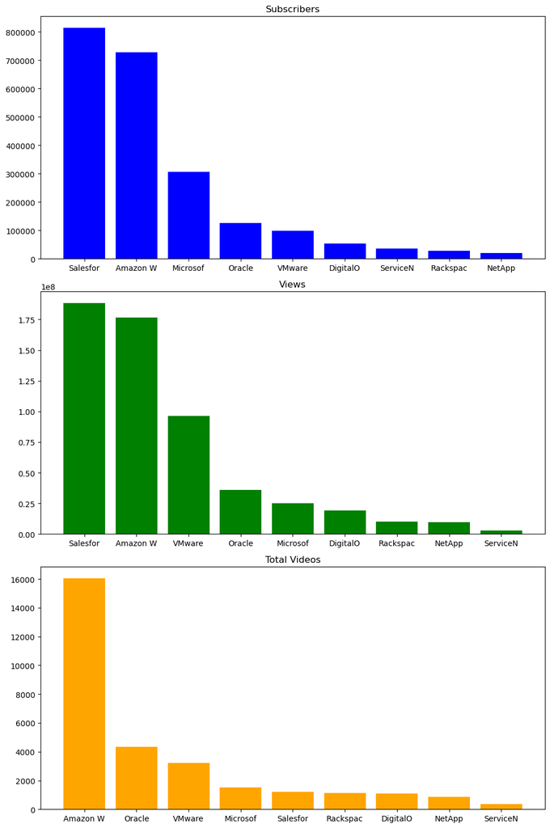

```python
import pandas as pd
import matplotlib.pyplot as plt

# Sort the DataFrame by 'Subscribers' in descending order
combined_Cloud_Service_channels_df_subscribers_sorted = combined_Cloud_Service_channels_df.sort_values(by='Subscribers', ascending=False)

# Shorten channel names
combined_Cloud_Service_channels_df_subscribers_sorted['Channel_name'] = combined_Cloud_Service_channels_df_subscribers_sorted['Channel_name'].apply(lambda x: x[:8])

# Plotting Subscribers in descending order
fig, axes = plt.subplots(nrows=3, ncols=1, figsize=(10, 15))

axes[0].bar(combined_Cloud_Service_channels_df_subscribers_sorted['Channel_name'], combined_Cloud_Service_channels_df_subscribers_sorted['Subscribers'], color='blue')
axes[0].set_title('Subscribers')

# Sort the DataFrame by 'Views' in descending order
combined_Cloud_Service_channels_df_views_sorted = combined_Cloud_Service_channels_df.sort_values(by='Views', ascending=False)

# Shorten channel names
combined_Cloud_Service_channels_df_views_sorted['Channel_name'] = combined_Cloud_Service_channels_df_views_sorted['Channel_name'].apply(lambda x: x[:8])

# Plotting Views in descending order
axes[1].bar(combined_Cloud_Service_channels_df_views_sorted['Channel_name'], combined_Cloud_Service_channels_df_views_sorted['Views'], color='green')
axes[1].set_title('Views')

# Sort the DataFrame by 'Total_videos' in descending order
combined_Cloud_Service_channels_df_total_videos_sorted = combined_Cloud_Service_channels_df.sort_values(by='Total_videos', ascending=False)

# Shorten channel names
combined_Cloud_Service_channels_df_total_videos_sorted['Channel_name'] = combined_Cloud_Service_channels_df_total_videos_sorted['Channel_name'].apply(lambda x: x[:8])

# Plotting Total Videos in descending order
axes[2].bar(combined_Cloud_Service_channels_df_total_videos_sorted['Channel_name'], combined_Cloud_Service_channels_df_total_videos_sorted['Total_videos'], color='orange')
axes[2].set_title('Total Videos')

# Adjust layout for better visibility
plt.tight_layout()

# Show the plot
plt.show()
```